# Examining Multicollinearity in Quarterback Statistics using Regularized Regression

Predicting Team Wins Based On QB Play

Author

Jonathan Sears, Jasmine Cole, Noah Miller

Published

July 20, 2026

Slides: slides.html

## Introduction

Under the stadium lights, the smell of popcorn and hot dogs and the band playing the “Fight Song” as one final play runs the last 3 seconds of the 4th quarter, that is the aesthetic of an American Football game. Fans come together to support, cheer and hope for their team’s victory. But what if fans or people in general had the ability to go into a match where they could predict the outcome? Being able to predict outcomes in the National Football League (NFL) through multi-dimensional data requires many different features and data such as home field advantage, player performance, team statistics, and game conditions which can cause multicollinearity, being a negative impact on the least square estimator in regression due to correlation between variables (McDonald 2009).

Previous NFL studies have successfully used machine learning methods such as Logistic Regression, Random Forests, and Support Vector Machines to predict NFL defensive player performance and game outcomes. In this study, we instead focus on Ridge and LASSO regression because these methods effectively address multicollinearity while maintaining predictive accuracy.(Gweon 2024; Juuri 2023). With the implementation of a machine learning regression model such as Least Absolute Shrinkage and Selection Operator (LASSO), and Ridge we can simplify the variables and focus only on the important aspects that help to accurately predict wins. The difference between LASSO and Ridge regression comes from how their penalties are calculated mathematically. LASSO uses a shrinkage technique called L1 regularization, where it zeros out the least important variables, leaving only variables that are optimal for accurate prediction. Ridge regression uses a shrinkage technique called L2 regularization where it helps reduce multicollinearity without removing variables from the original set of independent variables. This helps with some of the distortion of the predictors. Another area where Ridge differs from LASSO is that in the end and final model, Ridge retains all variables . LASSO is a “step-up” from Ridge allowing for key variable selection, where Ridge can struggle with its limitations due to retention of all variables. This highlights that LASSO’s ability to produce a subset of “key-variables” from a high-dimensional dataset, makes it highly efficient (Tibshirani 1996).

Previous research examining LASSO regression has consistently demonstrated its usefulness in datasets containing large numbers of predictors and correlated variables. Across applications in credit risks awareness (Geraldo-Campos et al. 2022), genetics, and other predictive modeling fields, LASSO has been shown to improve model interpretability by shrinking insignificant coefficients toward zero while retaining the most influential predictors (Bhattacharyya 2025; Jana and Hemalatha 2021; Lockhart et al. 2014). Sports outcomes in LASSO include ability to identify home-field advantage as a key-variable by narrowing down recruitment and box-score metrics (South and Egros 2020). Similarly, LASSO was utilized to significantly reduce computational complexity that identified an optimal configuration of motion sensors (Laufer et al. 2023). Such reduces model complexity and can improve predictive performance compared to traditional regression methods (Alshqaq and Abuzaid 2023; Bhattacharyya 2025; Lockhart et al. 2014). Studies have also shown that regularization techniques such as Ridge regression can effectively address multicollinearity by reducing coefficient variance without removing predictors from the model. One limitation discussed within the literature is that highly correlated variables can influence LASSO’s variable selection process, potentially causing relevant predictors to be excluded (Lockhart et al. 2014). Overall, the findings suggest that regularized regression methods provide a useful framework for prediction problems involving numerous and potentially correlated variables, making them applicable to NFL team performance analysis.

It is important to note, however, that LASSO has experienced some limitations in its performance ability in variable selection specifically with highly correlated variables and complex non-linear interactions. For example, LASSO regression was compared against XGBoost to determine which methodology proved to be the most accurate at predicting fare prices for online cab services, in which XGBoost outperformed LASSO because “LASSO failed to make the grouped selection as it only took one variable from a group and ignored the remaining variables,” (Tarun G and Sriramya 2026). Despite this specific limitation, across multiple studies LASSO proves to be consistent in its ability to minimize prediction error and utilize mathematical frameworks to isolate key critical variables.

The main goal of this report is to examine the impact of multicollinearity on predicting NFL team success and to examine whether regularized regression models are better than a linear regression model. This will be seen by comparing a standard linear regression, Ridge regression, and LASSO regression ability to predict the number of regular-season wins by an NFL team using that team’s quarterback’s performance statistics. Predictor variables include a quarterback’s season standard statistics, as well as expected points added (EPA), a metric that measures how many net points a quarterback adds to their team’s scoring potential on passing plays, compared to the league-average expectation for any given down, distance, and field position. This report will also aim to find which quarterback performance statistics are most influential in predicting team performance. Understanding the impact of a quarterback’s performance on a team’s success and the most influential quarterback performance statistics provide valuable information for NFL analysts, coaches, and teams trying to find players that contribute to team success and improve team performance.

## Methods

Following base cleaning of the data, numerical values were scaled to a mean of 0 and a standard deviation of 1 in an effort to preserve proportionate influence upon results. The data were standardized based upon:

$$x_{ij}^{\text{scaled}}
=
\frac{x_{ij}-\mu_j}{\sigma_j}$$

where $x_{ij}$ represents value of feature j for observation i, $\mu_j$ represents mean of feature j, and $\sigma_j$ represents standard deviation of feature j.

A standard linear regression (term used interchangeably with Ordinary Least Squares and OLS for the purposes of this report) is used as a baseline, calculated by:

$$y_i = \beta_0 + \sum_{j=1}^{p} \beta_j x_{ij} + \epsilon_i$$

where $y_i$ represents the observed response for observation i, $\beta_0$ represents the intercept term, $x_{ij}$ represents the value of predictor variable j for observation i, $\beta_j$ represents the coefficient associated with predictor, $j$ represents the index of the predictor variables, and $p$ represents the total number of predictor variables, and $\epsilon_i$ represents the random error term for observation i.

Exploratory analysis will reveal substantial multicollinearity among predictor variables. Because correlated predictors can produce unstable coefficient estimates in Ordinary Least Squares regression, regularized regression approaches will be used to improve model stability. LASSO and Ridge regression were selected because both methods reduce the impact of multicollinearity through coefficient shrinkage, while differing in their approach to variable retention and selection.

The LASSO regression equation upon the data was calculated by:

$$\hat{\boldsymbol{\beta}}
=
\arg\min_{\boldsymbol{\beta}}
\left\{
\sum_{i=1}^{n}
\left(
y_i-\beta_0-\sum_{j=1}^{p}\beta_jx_{ij}
\right)^2
+
\lambda\sum_{j=1}^{p}|\beta_j|
\right\}$$

where $\hat{\boldsymbol{\beta}}$ represents the estimated coefficient vector, $\lambda$ represents the regularization parameter, and $\lambda\sum_{j=1}^{p}|\beta_j|$ representing the L1 penalty.

The Ridge regression equation upon the data was calculated by:

$$\hat{\boldsymbol{\beta}}
=
\arg\min_{\boldsymbol{\beta}}
\left\{
\sum_{i=1}^{n}
\left(
y_i-\beta_0-\sum_{j=1}^{p}\beta_jx_{ij}
\right)^2
+
\lambda\sum_{j=1}^{p}\beta_j^2
\right\}$$

where $\lambda\sum_{j=1}^{p}\beta_j^2$ represents the L2 penalty.

For the LASSO and Ridge regression methods, the regularization parameter ($\lambda$) was selected using a 10-fold cross validation, defined as:

$$\mathrm{CV}_{10} = \frac{1}{10}\sum_{k=1}^{10} L_k$$

ensuring a practical 90/10 train-test split, a common approach for numerical datasets of less than 1000 observations. Within the function, the dataset is divided into ten equally sized subsets, where nine folds are used to train the model while the remaining fold is reserved for validation (testing). The process is repeated until each fold has served as the validation set exactly once, and the resulting validation errors are averaged to estimate the model’s predictive performance. By evaluating each candidate value of the regularization parameter ($\lambda$) across all ten folds, what is identified is the value that minimizes the cross-validated error. The use of 10-fold cross-validation provides a balance between computational efficiency and reliable model evaluation, allowing nearly all observations to contribute to both model training and validation throughout the procedure, without heightened risk of overfitting or underfitting.

$$\mathrm{RMSE}
=
\sqrt{
\frac{1}{n}
\sum_{i=1}^{n}
(y_i-\hat{y}_i)^2
}$$

where n represents the number of observations, $y_i$ represents the observed response value for observation i, $\hat{y}_i$ represents the predicted response value for observation i, and $y_i-\hat{y}_i$ represents the prediction error.

MAE provides a measure that is less sensitive to extreme observations, represented by:

$$\mathrm{MAE}
=
\frac{1}{n}
\sum_{i=1}^{n}
\left|y_i-\hat{y}_i\right|$$

R², however, measures the proportion of variation in the response variable explained by the model,represented by:

$$R^2 =
1 -
\frac{
\sum_{i=1}^{n}(y_i-\hat{y}_i)^2
}{
\sum_{i=1}^{n}(y_i-\bar{y})^2
}$$

where $\bar{y}$ represents the mean of the observed response values, $\sum_{i=1}^{n}(y_i-\hat{y}_i)^2$ represents the residual sum of squares, and $\sum_{i=1}^{n}(y_i-\bar{y})^2$ represents the total sum of squares.

Lower RMSE and MAE values, coupled with a higher R², indicate a model that more effectively balances prediction accuracy with the coefficient shrinkage introduced through regularization.

## Analysis and Results

### Data Description and Visualization

A study was conducted to determine how quarterback (QB) season statistics correlates with how many wins a team has in that season. To determine how QB statistics correlates with team wins in a season, the dataset was created using publicly available NFL data accessed through the R package nflreadr. Weekly quarterback player statistics and NFL game schedules were collected for the 2015 through 2024 regular seasons.

Quarterback performance data were obtained using the `load_player_stats()` function. The dataset was filtered to include only players whose position was quarterback (QB). Weekly statistics were then aggregated into season-level totals for each quarterback and team. The aggregated variables included passing yards, passing touchdowns, interceptions, completions, pass attempts, passing EPA, rushing yards, and rushing touchdowns. In addition, completion percentage was calculated by dividing total completions by total pass attempts and multiplying by 100.

Team performance data was collected using the `load_schedules()` function. Only regular-season games were included by filtering for `game_type == "REG"`. Wins were calculated separately for home and away teams by comparing the final scores of each game. Home and away wins were then combined to compute each team’s total number of regular-season victories for every season from 2015 through 2024.

The team win totals were merged with the quarterback season statistics using season and team as matching variables. Finally, quarterbacks with fewer than 200 pass attempts in a season were removed to ensure that the analysis included only quarterbacks with substantial playing time, reducing the influence of backup quarterbacks and small sample sizes.

The final dataset contains one observation for each qualifying quarterback-season and includes both individual performance statistics and the corresponding team’s regular-season win total. The description of variables are listed below in the chart.

```r
# loading packages
library(corrplot)
library(nflreadr)
library(dplyr)
```

```r
# Load Data

years = 2015:2024
weekly = load_player_stats(years)
qbs <- weekly %>%
  filter(position == "QB")
qb_season <- qbs %>%
  group_by(player_display_name, season, team) %>%
  summarize(
    passing_yards = sum(passing_yards, na.rm = TRUE),
    passing_tds = sum(passing_tds, na.rm = TRUE),
    interceptions = sum(passing_interceptions, na.rm = TRUE),
    completions = sum(completions, na.rm = TRUE),
    attempts = sum(attempts, na.rm = TRUE),
    passing_epa = sum(passing_epa, na.rm = TRUE),
    rushing_yards = sum(rushing_yards, na.rm = TRUE),
    rushing_tds = sum(rushing_tds, na.rm = TRUE)
  )

qb_season <- qb_season %>%
  mutate(
    completion_pct = (completions / attempts) * 100
  )

write.csv(qb_season, "qb_season_stats.csv", row.names = FALSE)

schedules <- load_schedules(2015:2024)
team_wins <- schedules %>%
  filter(game_type == "REG") %>%
  mutate(
    home_win = ifelse(home_score > away_score, 1, 0),
    away_win = ifelse(away_score > home_score, 1, 0)
  )

home_wins <- team_wins %>%
  group_by(season, team = home_team) %>%
  summarize(wins = sum(home_win, na.rm = TRUE))

away_wins <- team_wins %>%
  group_by(season, team = away_team) %>%
  summarize(wins = sum(away_win, na.rm = TRUE))

team_total_wins <- bind_rows(home_wins, away_wins) %>%
  group_by(season, team) %>%
  summarize(wins = sum(wins))

qb_season <- qb_season %>%
  left_join(team_total_wins,
            by = c("season", "team"))

write.csv(qb_season,
          "qb_season_dataset.csv",
          row.names = FALSE)

qb_season <- qb_season %>%
  filter(attempts >= 200)


write.csv(qb_season,
          "qb_season_dataset.csv",
          row.names = FALSE)

qb_season1 <- qb_season %>%
  ungroup() %>%
  select(-player_display_name, -season, -team)
```

```r
library(dplyr)
library(knitr)

variable_table <- data.frame(
  Variable = c(
    "passing_yards",
    "passing_tds",
    "interceptions",
    "completions",
    "attempts",
    "passing_epa",
    "rushing_yards",
    "rushing_tds",
    "completion_pct",
    "wins"
  ),
  Description = c(
    "Total number of passing yards recorded by the quarterback during the season.",
    "Total number of passing touchdowns thrown by the quarterback during the season.",
    "Total number of interceptions thrown by the quarterback during the season.",
    "Total number of completed passes by the quarterback during the season.",
    "Total number of pass attempts by the quarterback during the season.",
    "Total Expected Points Added (EPA) generated through passing plays during the season.",
    "Total number of rushing yards gained by the quarterback during the season.",
    "Total number of rushing touchdowns scored by the quarterback during the season.",
    "Completion percentage, calculated as (completions ÷ attempts) × 100.",
    "Total number of regular-season wins recorded by the quarterback's team (response variable)."
  ),
  Type = c(
    "Predictor",
    "Predictor",
    "Predictor",
    "Predictor",
    "Predictor",
    "Predictor",
    "Predictor",
    "Predictor",
    "Predictor",
    "Response"
  )
)

kable(variable_table,
      caption = "Table 1: Description of Variables Used in the Analysis")
```

Table 1: Description of Variables Used in the Analysis

| Variable | Description | Type |
| --- | --- | --- |
| passing_yards | Total number of passing yards recorded by the quarterback during the season. | Predictor |
| passing_tds | Total number of passing touchdowns thrown by the quarterback during the season. | Predictor |
| interceptions | Total number of interceptions thrown by the quarterback during the season. | Predictor |
| completions | Total number of completed passes by the quarterback during the season. | Predictor |
| attempts | Total number of pass attempts by the quarterback during the season. | Predictor |
| passing_epa | Total Expected Points Added (EPA) generated through passing plays during the season. | Predictor |
| rushing_yards | Total number of rushing yards gained by the quarterback during the season. | Predictor |
| rushing_tds | Total number of rushing touchdowns scored by the quarterback during the season. | Predictor |
| completion_pct | Completion percentage, calculated as (completions ÷ attempts) × 100. | Predictor |
| wins | Total number of regular-season wins recorded by the quarterback’s team (response variable). | Response |

Figure 1: Correlation Plot between Variables

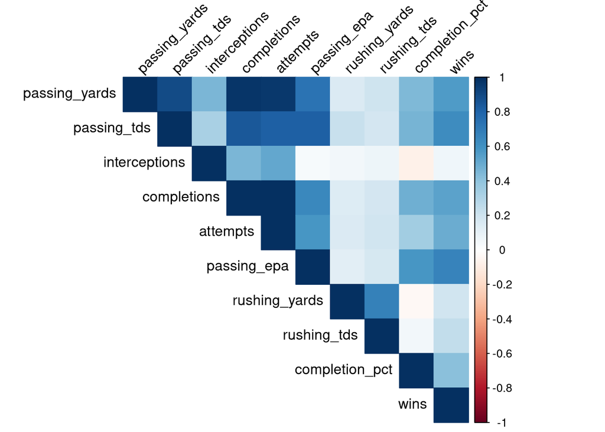

```r
correlation_matrix = round(cor(qb_season1, use = "complete.obs"), 2)
corrplot(correlation_matrix, method = "color", type = "upper",
         tl.col = "black", tl.srt = 45)
```

According to the correlation plot above, the passing EPA has the strongest correlation with team wins (r = 0.66). Completion percentage showed a moderate correlation with wins (r=0.41). The rushing statistics like rushing touchdowns and rushing yards appeared to have the lowest positive relationship with wins (average r= 0.22) while interceptions had almost no linear relationship with wins (r=0.06).

The analysis also identified substantial multicollinearity among several passing statistics. Completions and attempts were nearly perfectly correlated (r = 0.99), while passing yards showed very strong correlations with completions (r = 0.97) and attempts (r = 0.96). These findings suggest that some passing variables may provide redundant information and should be carefully considered during model development.

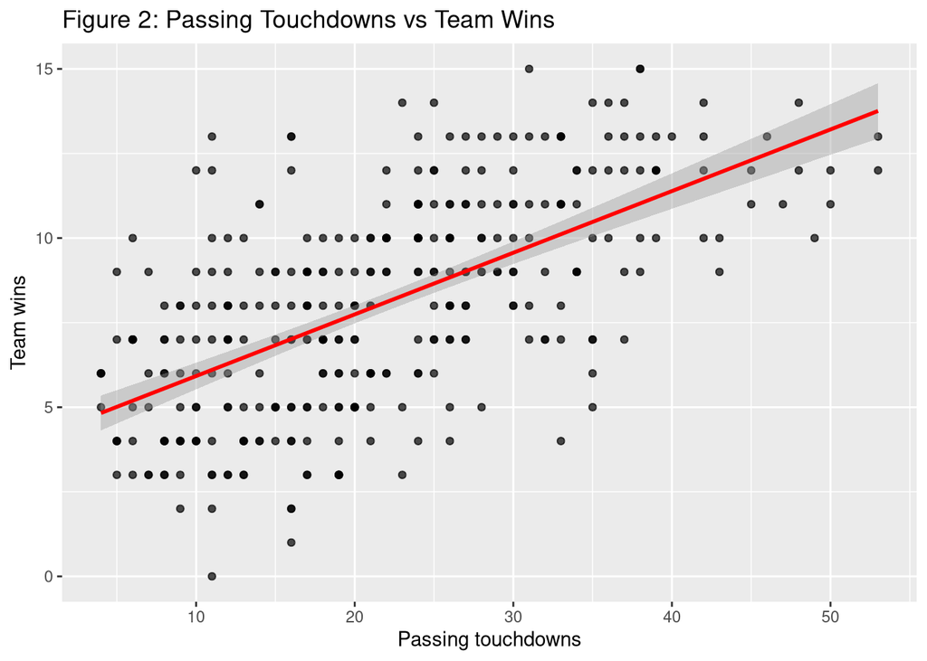

```r
library(ggplot2)

ggplot(qb_season1, aes(x = passing_tds, y = wins)) + geom_point(alpha = 0.7) + geom_smooth(method = "lm",color = "red") + labs(x="Passing touchdowns", y="Team wins", title = "Figure 2: Passing Touchdowns vs Team Wins")
```

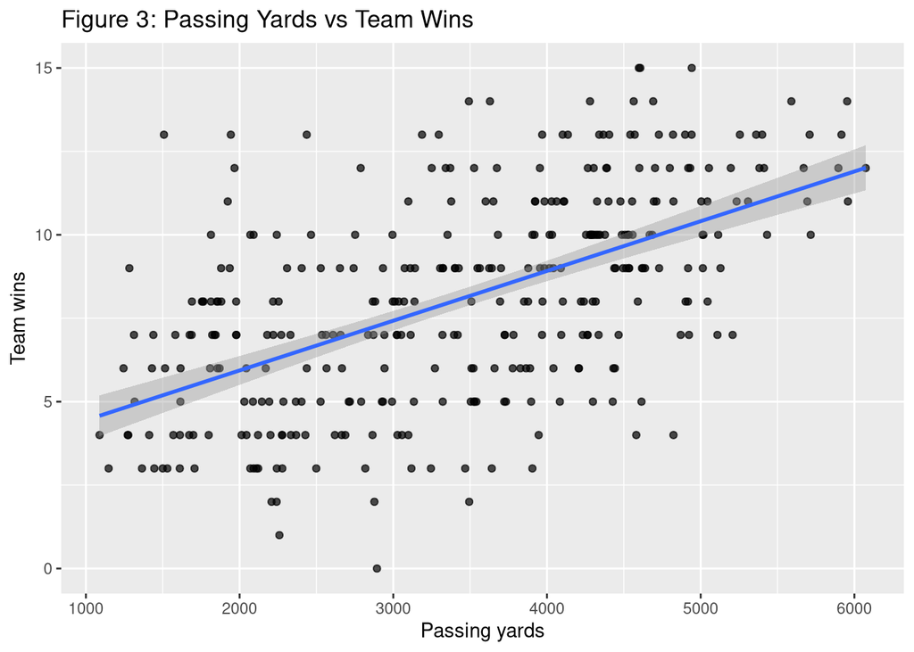

```r
ggplot(qb_season1, aes(x = passing_yards, y = wins)) + geom_point(alpha = 0.7) + geom_smooth(method = "lm") + labs(x="Passing yards", y="Team wins", title = "Figure 3: Passing Yards vs Team Wins")
```

Both scatterplots show that passing yards and passing touchdowns have a relative strong positive correlation to team wins. These scatterplots show that both variables, passing yards and passing touchdowns have a positive effect on team wins. The passing touchdowns versus team wins scatterplot shows a stronger relationship with less variability and spread in the data comparatively to passing yards versus team wins. The conclusion can be made that as passing touchdowns increase, team wins also increase and similarly as passing yards increase, team wins increase. This conclusion is beneficial in highlightling possible key variables that strongly influence team wins.

```r
VIF_Visualization_Model <- lm(wins ~ passing_yards + passing_tds + interceptions + completions + attempts + passing_epa + rushing_yards + rushing_tds + completion_pct, data = qb_season1)
library(car)
VIF_Visualization_Values <- vif(VIF_Visualization_Model)
VIF_Visualization_Values
```

```
 passing_yards    passing_tds  interceptions    completions       attempts
     45.086638       7.620450       1.795463     378.630209     340.548019
   passing_epa  rushing_yards    rushing_tds completion_pct
      7.333929       2.044880       1.956828      10.734847
```

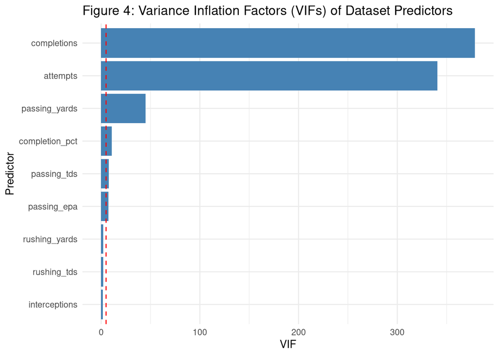

```r
VIF_Visualization_Dataframe <- data.frame(Variable = names(VIF_Visualization_Values), VIF = as.numeric(VIF_Visualization_Values))
library(ggplot2)
ggplot(VIF_Visualization_Dataframe, aes(x = reorder(Variable, VIF), y = VIF)) + geom_col(fill = "steelblue") + geom_hline(yintercept = 5, linetype = "dashed", color = "red") + coord_flip() + labs(title = "Figure 4: Variance Inflation Factors (VIFs) of Dataset Predictors", x = "Predictor", y = "VIF") + theme_minimal()
```

Variance Inflation Factors (VIFs) of the predictors against the response variable (wins) are modeled based on a simple linear regression created for the purposes of this visualization. To combat inflated variances due to predictor multicollinearity, a VIF threshold of 5 was used, exhibited by the red-dashed line running along the y-axis. Predictors such as interceptions, rushing_tds, and rushing_yards satisfy this threshold. Although completion_pct, passing_tds, and passing_epa do not meet the threshold, they are close enough to at least consider in a final model if other evidence supports their inclusion. Completions, attempts, and passing_yards, however, indicate such high variances that they should likely not be used when refining a model.

### Statistical Modeling

After collecting the quarterback and team data, several preprocessing steps were performed to prepare the dataset for analysis.

First, weekly quarterback statistics were aggregated into season-level totals for each quarterback and team from the 2015–2024 NFL regular seasons. Team regular-season win totals were calculated separately from the schedule data by summing home and away victories and then merged with the quarterback statistics using the season and team as matching variables.

A new variable, completion percentage, was created by dividing total completions by total pass attempts and multiplying by 100. This provided an additional measure of passing efficiency beyond the raw completion and attempt totals.

To ensure that only quarterbacks with meaningful playing time were included, seasons in which a quarterback attempted fewer than 200 passes were removed from the dataset. This filtering step reduced the influence of backup quarterbacks and players with limited appearances whose statistics may not be representative of a full season.

Variables that were not used as predictors, including the quarterback’s name, season, and team, were removed before model development. The remaining dataset consisted of nine predictor variables: passing yards, passing touchdowns, interceptions, completions, pass attempts, passing EPA, rushing yards, rushing touchdowns, and completion percentage. The response variable was the team’s total number of regular-season wins.

Before fitting the predictive models, the predictor variables were standardized so that each feature had a mean of zero and a standard deviation of one. Standardization places variables measured on different scales onto a common scale, improving model performance and ensuring that variables with larger numerical ranges do not disproportionately influence the results, particularly for regularization methods such as Ridge and LASSO regression.

Finally, the cleaned dataset was randomly partitioned into training and testing sets using an 90/10 split. The training set, containing 90% of the observations, was used to fit and tune the predictive models, while the remaining 10% served as an independent test set for evaluating model performance on unseen data.

```r
# Removal of non-numeric variables.

drop_vars <- c("player_display_name", "season", "team")
qb_season <- qb_season
qb_season <- qb_season[, !(names(qb_season) %in% drop_vars)]

# Scaling of numeric variables.

qb_scaled <- qb_season
predictor_cols <- setdiff(names(qb_scaled), "wins")

qb_scaled[predictor_cols] <- scale(qb_scaled[predictor_cols])

# Creation of train/test split.

set.seed(123)
train_index <- sample(seq_len(nrow(qb_scaled)), 0.9 * nrow(qb_scaled))

train <- qb_scaled[train_index, ]
test  <- qb_scaled[-train_index, ]

# Removal of missing values.

train <- na.omit(train)
test  <- na.omit(test)

# Simple regression model creation.

LinReg <- lm(wins ~ ., data = train)

# Matrix design in preparation for glmnet.

x_train <- model.matrix(wins ~ ., data = train)[, -1]
y_train <- train$wins
x_test_raw <- model.matrix(wins ~ ., data = test)[, -1]
x_test <- x_test_raw[, colnames(x_train), drop = FALSE]

# Ridge and Lasso creation including 10-fold cross-validation.

library(glmnet)
set.seed(123)
ridge_cv <- cv.glmnet(x_train, y_train, alpha = 0, nfolds = 10)
set.seed(123)
lasso_cv <- cv.glmnet(x_train, y_train, alpha = 1, nfolds = 10)


# Training predictions
ols_train_pred <- predict(LinReg, newdata = train)
ridge_train_pred <- as.vector(predict(ridge_cv, newx = x_train, s = "lambda.min"))
lasso_train_pred <- as.vector(predict(lasso_cv, newx = x_train, s = "lambda.min"))


# Prediction utilizing the test set.

ols_pred   <- predict(LinReg, newdata = test)
ridge_pred <- as.vector(predict(ridge_cv, newx = x_test, s = "lambda.min"))
lasso_pred <- as.vector(predict(lasso_cv, newx = x_test, s = "lambda.min"))

# Calculation of metrics.

rmse <- function(y, yhat) sqrt(mean((y - yhat)^2))
mae  <- function(y, yhat) mean(abs(y - yhat))
r2   <- function(y, yhat) 1 - sum((y - yhat)^2) / sum((y - mean(y))^2)

# Evaluation based on sought-after metrics.

lin_coef <- coef(LinReg)

comparison <- data.frame(
  Variable = names(lin_coef),
  Linear = as.numeric(lin_coef),
  Ridge = as.numeric(coef(ridge_cv, s = "lambda.min")),
  LASSO = as.numeric(coef(lasso_cv, s = "lambda.min"))
)
kable(comparison, caption = "Table 2: Comparison of Linear, Ridge, and Lasso Regression Coefficients for Predicting Team Wins")
```

Table 2: Comparison of Linear, Ridge, and Lasso Regression Coefficients for Predicting Team Wins

| Variable | Linear | Ridge | LASSO |
| --- | --- | --- | --- |
| (Intercept) | 8.0709986 | 8.0716689 | 8.0704357 |
| passing_yards | -1.2568986 | 0.1187192 | 0.0000000 |
| passing_tds | 0.5211971 | 0.5197706 | 0.4516282 |
| interceptions | -0.2079241 | -0.2822239 | -0.2338781 |
| completions | -0.1124531 | 0.1953686 | 0.4005406 |
| attempts | 1.4482299 | 0.1706525 | 0.0000000 |
| passing_epa | 1.5852628 | 1.0034750 | 1.2689360 |
| rushing_yards | 0.0795855 | 0.0932497 | 0.0646419 |
| rushing_tds | 0.3213856 | 0.2959374 | 0.3119702 |
| completion_pct | 0.2195101 | 0.2123187 | 0.0952512 |

An unexpected result from the linear regression model was the negative coefficient for passing yards (-1.257). Although higher passing yard totals are generally expected to contribute positively to team success, this coefficient represents the relationship between passing yards and wins while holding the other quarterback statistics constant. Since passing yards are highly correlated with variables such as attempts and completions, multicollinearity may have influenced the coefficient estimate and resulted in a counterintuitive direction. The Ridge and Lasso models reduce this issue by shrinking coefficients and reducing the influence of correlated predictors.

```r
num_predictors <- ncol(x_train)

ols_predictors <- num_predictors
ridge_predictors <- num_predictors

# Count nonzero coefficients (excluding intercept)
lasso_predictors <- sum(coef(lasso_cv, s = "lambda.min")[-1] != 0)

results <- data.frame(
  Model = c("OLS", "Ridge", "LASSO"),

  Predictors = c(
    ols_predictors,
    ridge_predictors,
    lasso_predictors
  ),

  Train_RMSE = c(
    rmse(train$wins, ols_train_pred),
    rmse(train$wins, ridge_train_pred),
    rmse(train$wins, lasso_train_pred)
  ),

  Train_MAE = c(
    mae(train$wins, ols_train_pred),
    mae(train$wins, ridge_train_pred),
    mae(train$wins, lasso_train_pred)
  ),

  Train_R2 = c(
    r2(train$wins, ols_train_pred),
    r2(train$wins, ridge_train_pred),
    r2(train$wins, lasso_train_pred)
  ),

  Test_RMSE = c(
    rmse(test$wins, ols_pred),
    rmse(test$wins, ridge_pred),
    rmse(test$wins, lasso_pred)
  ),

  Test_MAE = c(
    mae(test$wins, ols_pred),
    mae(test$wins, ridge_pred),
    mae(test$wins, lasso_pred)
  ),

  Test_R2 = c(
    r2(test$wins, ols_pred),
    r2(test$wins, ridge_pred),
    r2(test$wins, lasso_pred)
  )
)

kable(
  results,
  digits = 3,
  caption = "Table 3: Comparison of Training and Test Performance for OLS, Ridge, and LASSO Regression Models"
)
```

Table 3: Comparison of Training and Test Performance for OLS, Ridge, and LASSO Regression Models

| Model | Predictors | Train_RMSE | Train_MAE | Train_R2 | Test_RMSE | Test_MAE | Test_R2 |
| --- | --- | --- | --- | --- | --- | --- | --- |
| OLS | 9 | 2.285 | 1.856 | 0.470 | 1.987 | 1.588 | 0.579 |
| Ridge | 9 | 2.299 | 1.868 | 0.463 | 2.020 | 1.623 | 0.565 |
| LASSO | 7 | 2.294 | 1.863 | 0.466 | 1.975 | 1.591 | 0.584 |

Table 3 compares the training and testing performance of the Ordinary Least Squares (OLS), Ridge, and LASSO regression models used to predict team wins based on quarterback performance statistics. Overall, all three models produced similar results, suggesting that regularization had a limited impact on predictive accuracy for this dataset.

The comparison of training and testing performance indicates no strong evidence of overfitting or underfitting among the OLS, Ridge, or LASSO regression models. Training and testing errors were similar across all models, suggesting that the models generalized well to unseen data. Additionally, the test $R^2$ values were slightly higher than the training $R^2$ values, indicating that the models did not simply memorize the training data. However, because the models explain approximately 58% of the variance in team wins, there may be some degree of underfitting due to the limited set of predictors. Additional factors such as defensive performance, coaching decisions, injuries, and strength of schedule may improve predictive performance.

On the training set, OLS achieved the lowest RMSE (2.285) and MAE (1.856) with an $R^2$ of 0.470, indicating that it explained approximately 47% of the variation in team wins. Ridge regression produced slightly higher error values (RMSE = 2.299, MAE = 1.868) and a slightly lower $R^2$ (0.463), showing that coefficient shrinkage slightly reduced training performance. LASSO regression performed similarly to OLS, while reducing the number of predictors from 9 to 7 through feature selection.

On the testing set, LASSO achieved the strongest predictive performance with the lowest RMSE (1.975), a comparable MAE (1.591), and the highest $R^2$ value (0.584). OLS performed closely behind with a test RMSE of 1.987 and $R^2$ of 0.579, while Ridge had the weakest test performance with an RMSE of 2.020 and $R^2$ of 0.565. The slightly improved test performance of LASSO suggests that removing less influential predictors helped improve model generalization and reduce unnecessary complexity.

Although LASSO selected fewer predictors, the differences among the three models were relatively small. This indicates that quarterback statistics contain meaningful predictive information for team wins, but additional factors such as defensive performance, coaching, injuries, and strength of schedule likely contribute significantly to team success. The results demonstrate that regularization methods, particularly LASSO, can provide a more efficient model while maintaining or slightly improving predictive accuracy.

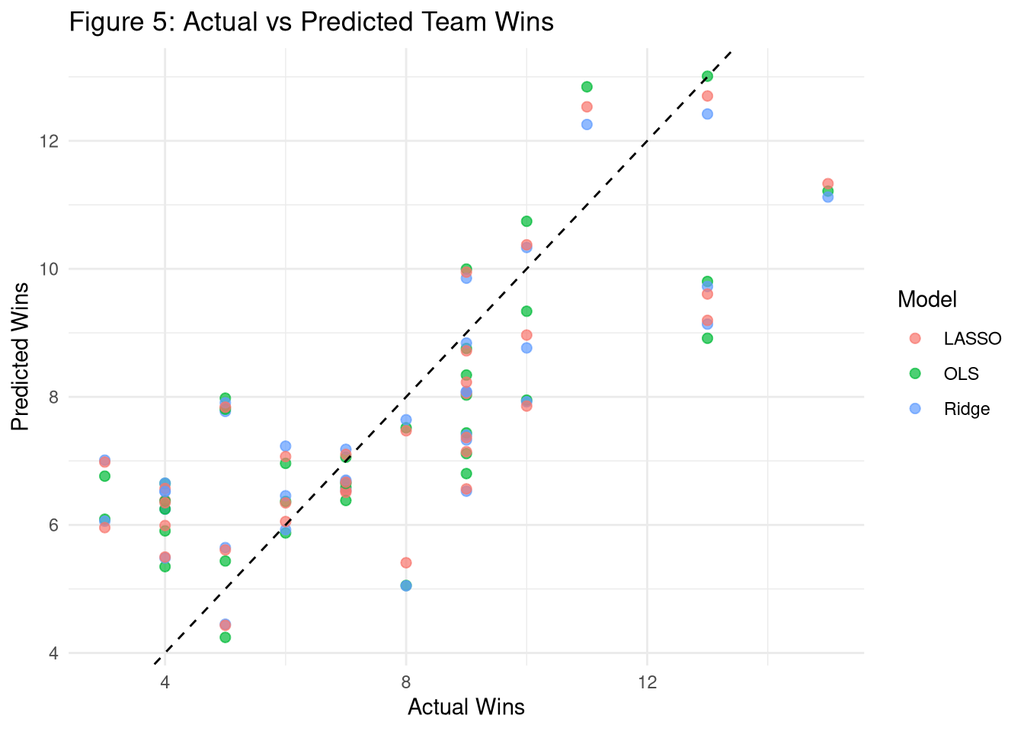

```r
predictions <- data.frame(
  Actual = test$wins,
  OLS = ols_pred,
  Ridge = ridge_pred,
  LASSO = lasso_pred
)

#head(predictions)

library(tidyr)
library(ggplot2)

predictions_long <- predictions %>%
  pivot_longer(
    cols = c(OLS, Ridge, LASSO),
    names_to = "Model",
    values_to = "Predicted"
  )

ggplot(predictions_long, aes(x = Actual, y = Predicted, color = Model)) +
  geom_point(alpha = 0.7, size = 2) +
  geom_abline(
    slope = 1,
    intercept = 0,
    linetype = "dashed"
  ) +
  labs(
    title = "Figure 5: Actual vs Predicted Team Wins",
    x = "Actual Wins",
    y = "Predicted Wins"
  ) +
  theme_minimal()
```

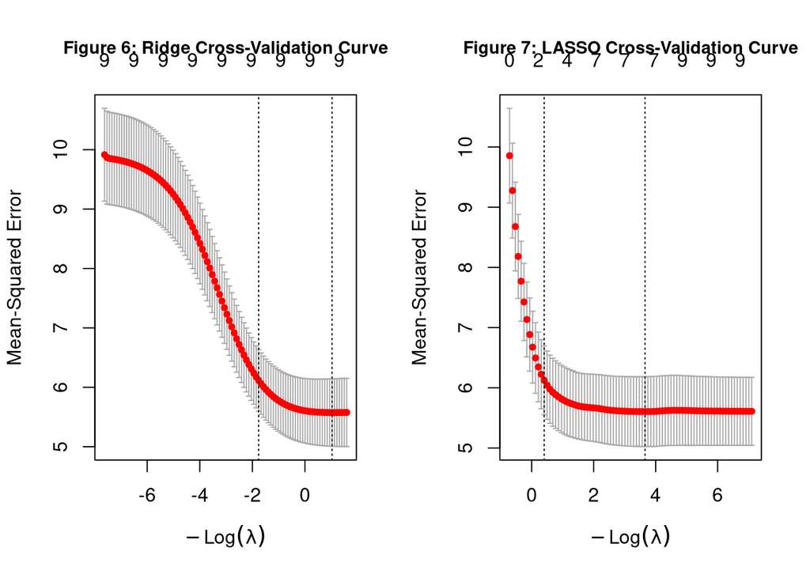

```r
par(mfrow = c(1,2), cex.main = 0.9)

plot(ridge_cv)
title("Figure 6: Ridge Cross-Validation Curve")

plot(lasso_cv)
title("Figure 7: LASSO Cross-Validation Curve")
```

Figures 6 and 7 show how cross-validation was used to identify the optimal regularization parameter ($\lambda$) for both Ridge and LASSO regression models. The cross-validation curves demonstrate that prediction error decreased as the strength of regularization was reduced, reaching a minimum at the selected $\lambda$ value. Further reductions in regularization resulted in minimal improvements in prediction error, indicating that the selected $\lambda$ provided an appropriate balance between model complexity and predictive accuracy. The $\lambda$ values corresponding to the minimum cross-validation error were used to fit the final Ridge and LASSO models.

```r
#ols_resid   <- test$wins - ols_pred
#ridge_resid <- test$wins - ridge_pred
#lasso_resid <- test$wins - lasso_pred

#residuals_df <- bind_rows(
  #data.frame(Predicted = ols_pred,
             #Residual = ols_resid,
             #Model = "OLS"),
  #data.frame(Predicted = ridge_pred,
             #Residual = ridge_resid,
             #Model = "Ridge"),
  #data.frame(Predicted = lasso_pred,
             #Residual = lasso_resid,
             #Model = "LASSO")
#)

#ggplot(residuals_df,
       #aes(x = Predicted, y = Residual)) +
  #geom_point(alpha = 0.7) +
  #geom_hline(yintercept = 0, color = "red") +
  #facet_wrap(~Model) +
  #labs(
    #title = "Residual Plots by Model",
    #x = "Predicted Team Wins",
    #y = "Residual"
  #)
```

## Conclusion

This research evaluated LASSO and Ridge regression against a baseline Ordinary Least Squares model to predict team wins using quarterback performance statistics. This research examined the impact of multicollinearity on team wins in the NFL and determined key quarterback statistics that influence team success.

Prior to researching the linear regression model compared to LASSO and Ridge regularized regression model, the correlation plot from Figure 1 shows an almost perfect correlation between passing statistics such as completions and pass attempts (r=0.99) and passing yards (r=0.96) and EPA gave the strongest correlation with team wins (r=0.66) and completion percentage gave a moderately positive correlation with team wins (r=0.41).

Figures 2 and 3 indicated possible strong positive correlation between team wins versus passing yards and team wins versus passing touchdowns preemptively suggesting these to be key variables in predicting team wins. However, as shown in table 2, the baseline Ordinary Least Squares (OLS) model in this research gave a negative coefficient for passing yards possibly being influenced by multicollinearity due to passing yards being highly correlated with other predictors such as completions and attempts. While passing touchdowns and passing EPA are consistent in all 3 models, indicating to be key predictors of team success.

Although OLS appears similar in this comparison result, its previous erratic coefficient value from earlier diagnostics causes concern for interpretability. Overall even though OLS seemed to perform similarly to LASSO and Ridge slightly in model performance metrics (RSME, MAE and $R^2$), LASSO and Ridge with their shrinking techniques helped to reduce the overall impact of multicollinearity more efficiently than OLS suggesting that traditional linear regression methods could be uncertain when facing complex and highly correlated variables. LASSO proved to be the best methodology overall comparatively with its feature selection, low RSME and MAE and high $R^2$.

This research helped to highlight the key variables of quarterback statistics that contribute to team successes through regularized regression, LASSO being the best methodology. Which can prove beneficial for future prediction and team recruitment by providing an interpretable foundation of how a quarterback’s performance impacts team wins.

## References

Alshqaq, S. S., and A. H. Abuzaid. 2023. “An Efficient Method for Variable Selection Based on Diagnostic-Lasso Regression.” *Symmetry* 15 (12): 2155. https://doi.org/10.3390/sym15122155.

Bhattacharyya, J. 2025. *LASSO Regression: A Procedural Improvement*. No. 5108591. SSRN. https://doi.org/10.2139/ssrn.5108591.

Geraldo-Campos, L. A., J. J. Soria, and T. Pando-Ezcurra. 2022. “Machine Learning for Credit Risk in the Reactive Peru Program: A Comparison of the Lasso and Ridge Regression Models.” *Economies* 10 (8): 1–21. https://doi.org/10.3390/economies10080188.

Gweon, J. 2024. “Comparing Different Machine Learning Methods on NFL Defensive Player Performance Prediction.” Master’s thesis, Kansas State University. https://krex.k-state.edu/items/b5cae4fb-f772-42ce-9dad-d7a84094e8bf.

Jana, A., and S. Hemalatha. 2021. “Football Player Performance Analysis Using Particle Swarm Optimization and Player Value Calculation Using Regression.” *Journal of Physics: Conference Series* 1911 (1): 012011. https://doi.org/10.1088/1742-6596/1911/1/012011.

Juuri, S. 2023. “Predicting the Results of NFL Games Using Machine Learning.” Master’s thesis, Aalto University. https://aaltodoc.aalto.fi/items/8a329777-bdfe-4800-8d8d-d6dc3e75be70.

Laufer, B., P. D. Docherty, R. Murray, et al. 2023. “Sensor Selection for Tidal Volume Determination via Linear Regression: Impact of Lasso Versus Ridge Regression.” *Sensors* 23 (17): 7407. https://doi.org/10.3390/s23177407.

Lockhart, Richard, Jonathan Taylor, Ryan J. Tibshirani, and Robert Tibshirani. 2014. “A Significance Test for the Lasso.” *The Annals of Statistics* 42 (2): 413–68. https://doi.org/10.1214/13-AOS1175.

McDonald, Gary C. 2009. “Ridge Regression.” *WIREs Computational Statistics* 1 (1): 93–100. https://doi.org/10.1002/wics.14.

South, C., and E. Egros. 2020. “Forecasting College Football Game Outcomes Using Modern Modeling Techniques.” *Journal of Sports Analytics* 6 (1): 25–33.

Tarun G, Venkat Sai, and P. Sriramya. 2026. “Analyzing OLA Data for Precise Price Prediction Using XGBoost Technique Comparing with Lasso Regression.” In *Advances in Parallel Computing Algorithms, Tools and Paradigms*. SAGE Publications. https://doi.org/10.3233/APC220050.

Tibshirani, Robert. 1996. “Regression Shrinkage and Selection via the Lasso.” *Journal of the Royal Statistical Society: Series B (Methodological)* 58 (1): 267–88. https://doi.org/10.1111/j.2517-6161.1996.tb02080.x.